# Your Digest for Friday, Apr 19, 2024 03:59 PM

- Bag fibers and chain fibers are both innervated by Type 1 neurons -> Group Ia = *annulospiral*. They are naked neuron endings wrapping around the central parts of the intrafusal fibers.
- Chain fibers are innervated by Type 2 neurons as well. -> Group II = "*flower spray*" neurons. They innervate the distal ends of the chain fibers.
- The lengthening and shortening of muscles is detected by the muscle spindles.
- The tension of the muscle is detected by the tendon spindles. (Golgi tendon organ)  
  ⭐

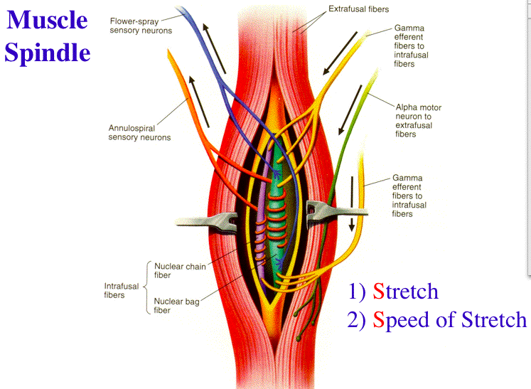

Some forms of familial distal [[2021-SBR-November#Renal tubular acidosis|renal tubular acidosis]] arises from band-3 malfunction.

[figure not shown]

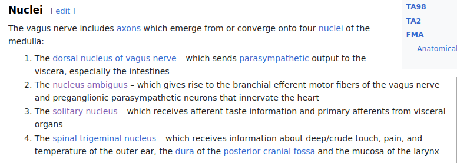

  - It sends output to the gut upto the distal transverse colon (midgut / hindgut junction)
- **Nucleus ambiguus** -> supplies efferent fibers to striated muscle of the pharynx and larynx and parasympathetics to the heart.
- Superior laryngeal branch supplies larynx above the vocal folds.
- Recurrent laryngeal nerve is given off the right vagus nerve.
- The vagi enter the abdomen through the oesophageal opening of the diaphragm.

```
- **Treatment**: gangiclovir, valcanciclovir etc. (*valganciclovir is the oral prodrug*).
    - Ganciclovir becomes activated in viral infected cells and inhibits viral DNA polymerases.
```

- Clinical and with detection of expansions of the FXN gene.

### Derterminants of myocardial O2 consumptions:

[Source](https://derangedphysiology.com/main/cicm-primary-exam/required-reading/cardiovascular-system/Chapter%20032/myocardial-oxygen-supply-and-demand)

| Major determinants | Minor determinants |
| --- | --- |
| Heart rate (main one) | Preload is a minor contributor |
| Contractility |  |
| Afterload |  |

Of the myocardial oxygen consumption, *60% of is used for contraction*, **15% for relaxation**, 20% for basal metabolism and 3-5% for electrical activation.

> [!INFO] Direct Xa inhibitors affect the PT/INR more than the APTT  
> [Source](https://www.ncbi.nlm.nih.gov/pmc/articles/PMC4952533/)

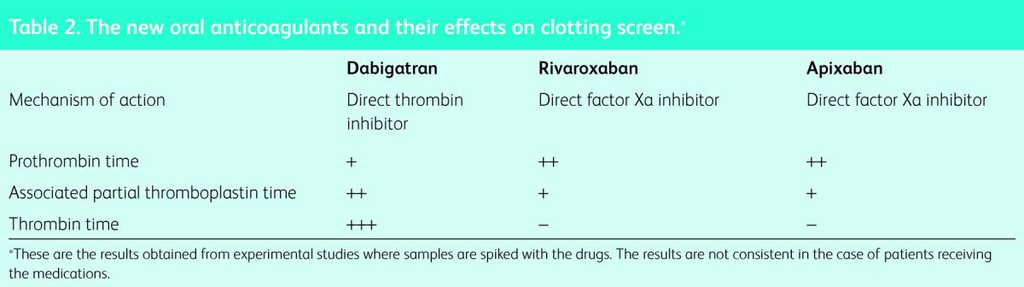

Clostridium tetani is a *gram positive rod*. It will not grow in healthy tissues.

- Tetanospasmin is an *exotoxin* produced by the bacteria.  
  ⭐It **enters *peripheral* motor nerves** and **travels to the CNS** where it *inhibits GABA (which is itself inhibitory)*. There is subsequent *loss of inhibition* of the anterior horn cells -> painful muscle spasm.
- Loss of inhibition of autonomic nerves: *Severe ⭐autonomic instability*; **sweating, tachycardia and hypertension**.
- The effects on the neurons are **long lasting** because recovery **requires the growth of ⭐new axonal nerve terminals**

> [!INFO] Vitamin K deficiency  
> Early vitamin K deficiency affects only the PT, not the APTT, despite the fact that the vitamin K-dependent factors (II, VII, IX and X) should affect both the intrinsic and the extrinsic pathways.  
> [Source](https://www.ncbi.nlm.nih.gov/pmc/articles/PMC4952533/).  
> More significant vit K deficiency will cause prolongation of both APTT and PT.

A mutated version of **factor V** which leads to Factor Va which is *resistant to inactivation by protein C.*  
5% prevalence in Europeans  
Associated with fivefold risk of VTE. **Synergistic risk with OCP and pregnancy.**  
-- but overall *still very low absolute risk*.

```
2. Cryptococcus neoformans : **yeast**, harmless colonizer of airway in healthy persons; infections rare in healthy people. *Pigeon dropping*, unwashed fruit.
3. ![CryptococcusHistology.png](CryptococcusHistology.png)
4. Usually begins as a pulmonary infection -> *cough*.
5. Can cause *meningitis*.(Mnemonic: "*Bird brain*")
6. "Histoplasmosis is associated with bird or bat droppings in soil, while cryptococcosis has a broader environmental distribution." - Bing Copilot
```

3. **Cryptosporidium** - **if > 1 month**

**Zoonosis**; Obligate intracellular, gram -ve *bacterium*. Commonest reservoir is goats, cattle, cats.

- *Pneumonia*
- **Hepatitis**  
  *Chronic infection* manifests as **endocarditis**, **osteomyelitis** **uveitis** and other local infection.  
  **Cannot culture.** Serology is used for diagnosis.

[figure not shown]

[output not shown]